# Article 1

Justin Yee

10/25/2018

## Keys to Success for the Young Lakers Core

[figure not shown]

lonzowire.usatoday.com

#### Exploring the Data

To start my stastical analyisis, I began by exploring the data. First, we can take a quick look at the distributions of Game Score for each player, as well as comparing the mean Game Score for each player in the following charts.

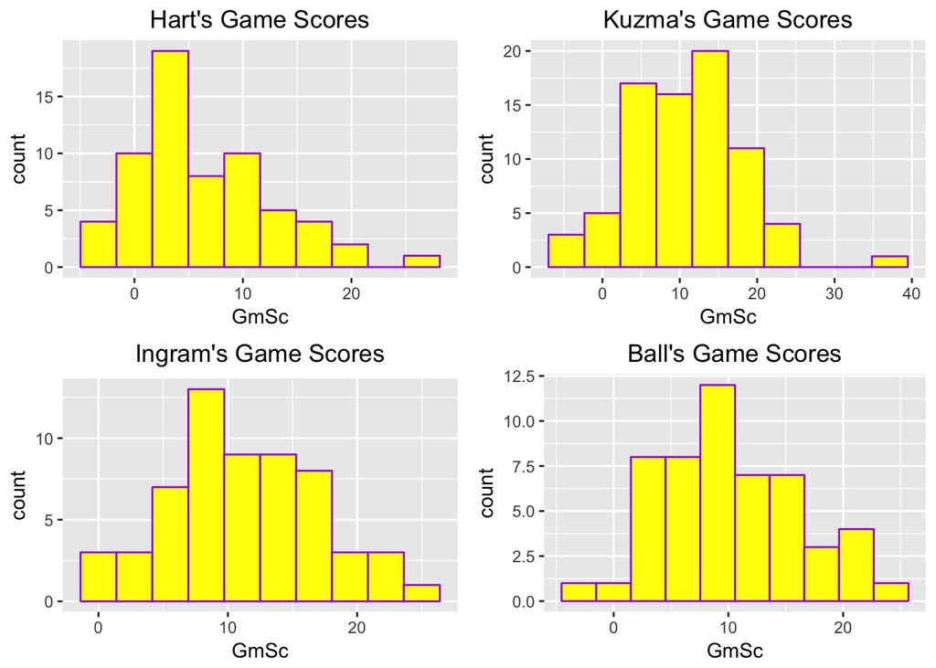

From these histograms, we can notice that the distribution of the Game Score’s were roughly similiar to normal distributions with the exception of outliers. We want to capture what the greatest predictors are of each individual’s Game Score relative to their own average performance on the year. In other words, we want to find out exactly *what* that player did exceptionally well or exceptionally poorly to merit a good or bad game score.

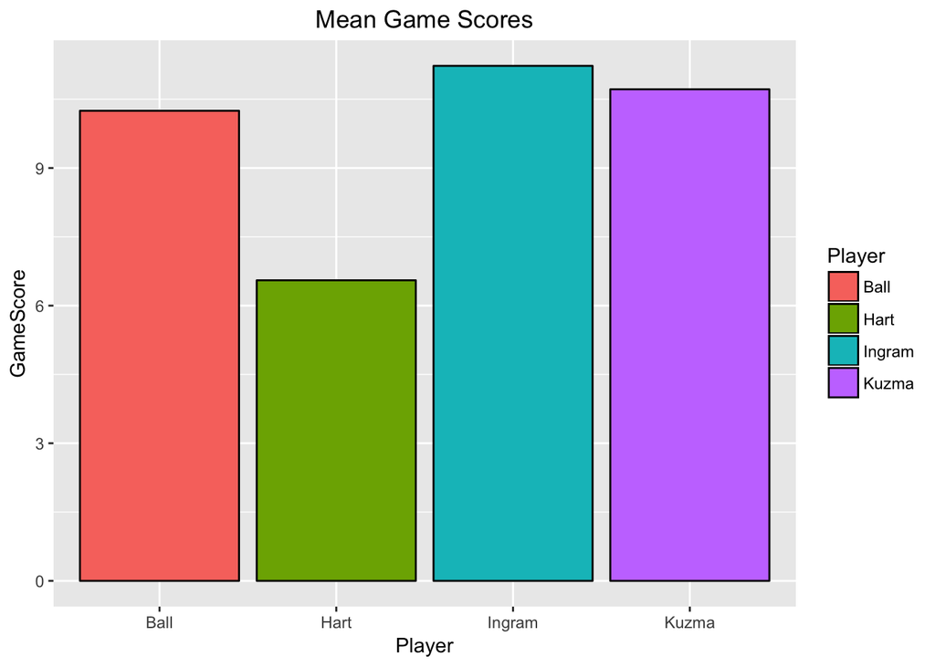

In the above chart we can see the average Game Scores for each player for the 2017-2018 season. Visually, we can see that the young core all have about the same average Game Scores, with the exception of Hart, who played the least amount of minutes.

#### Methodology and Rationale

From a statistical standpoint, my primary methodology predicting the Game Score statstic using variables from the game logs as my predictive variables through a multiple linear regression model. The rationale behind choosing such a model is for interperatable purposes, as it is clear from the output of this model the effects of each variable in predicting the statistic Game Score.

An essential part of building these models is the question of normalizing the data. Ultimately, I decided I wanted to normalize by individual since this will tell us what the individual should work on more for their own personal game, not compared to everyone else.

To build the models, I tested the subsets up to a total of five predictors through an exhaustive search, choosing the model with the highest adjusted R<sup>2</sup>. If you are interested in learning more about the models built or datasets you can visit the datasets and code on my [github](https://github.com/jgyee/BSA-Young-Lakers-Data-Game-Score-Analysis). The following charts below summarize my results for these models.

Model Coefficients for Each Player

|  | Hart | Kuzma | Ingram | Ball |
| --- | --- | --- | --- | --- |
| Intercept | 6.5523810 | 10.715584 | 11.227119 | 10.248077 |
| FG | 7.0236542 | 6.851481 | 7.039416 | 6.503627 |
| FGA | -3.4908755 | -2.411566 | -2.872533 | -2.696985 |
| FT | 1.5759834 | 2.284202 | 1.497359 | 0.000000 |
| AST | 1.6627760 | 1.618518 | 1.747599 | 1.969441 |
| STL | 0.7679265 | 0.000000 | 0.000000 | 1.245747 |
| TOV | 0.0000000 | -1.717221 | -1.428057 | -1.316189 |

#### Finding the Keys to Success

Let us now break up the models and analyze each separately, giving recommendations to each player their “keys to success”, and what parts of their game they should work on more, basing our suggestions on the coefficients of the models.

[figure not shown]

lonzowire.usatoday.com

For Hart, his field goal atempts most drastically affects his Gamescore negatively relative to his fellow teammates, meaning he should focus on better shot attempts. Although Hart’s field goal percentage of 47% is remarkable for a rookie guard, the results of this model suggest that Hart can still improve his game by choosing his shots more wisely. The other coefficients of Hart’s model rank all fairly high compared to the rest of the young core, alluding to Hart’s strong overall game and lack of offensive deficiencies.

For Kuzma, his turnovers most adversely affect his Gamescore negatively in comparison to the other players, meaning he should focus on being more careful with the ball. In addition, his field goal attempts do not dramatically decrease his Gamescore compared to his fellow teammates. These two factors may be indicative of Kuzma continuing to be aggressive shooting the ball, but to temper that aggression with more patience when driving or passing, which can lead to costly turnovers.

For Ingram, his field goals most positively improve his performance, so he should focus on staying aggressive and being a primary scoring option. His free throw coefficient is lagging behind that of Kuzma and Hart, suggesting that free throws are a large part of his game he can work on. To improve, he can focus on drawing more fouls and get to the line more. Additionally, he can improve his free throw percentage, so that when he does get to the line, he converts those attempts into points.

For Ball, his assists and steals most positively affect his Gamescore relative to the other three players. Unsurprisingly, Lonzo’s passing is the strongest part of his game and contributes to the majority of his success in his best games. His made field goals contribute the least to his Gamescore relative to the other three players. For him to succeed, he must keep his assists up, maintain aggressive on defensive possessions, as well as improve on his scoring ability.

Looking across the various models, we have noticed some differences between the players. These results are somewhat suprising, as they give us a different perspective than looking at a player’s overall season statistics, such as Josh Hart’s 47% FG% on the season telling us that he is an efficient scorer. This compared to Lonzo Ball’s shockingly-low 36% FG% from last season. However, we must keep in mind that these statistics are normalized, so they are adjusted for in respect to that player’s average performance. This is the key lense of our models we must look through in order to interpret and know why the results are the way they are.

#### Conclusion and Further Remarks

There are two key aspects of our analysis that differentiate it from the typical, more basic analysis of a player’s performance. From the perspective of looking at singular games rather than a whole season, we can find different results that may give us deeper insight into the success of these players solely on a game-to-game basis. Addtionally, choosing to normalize based on that player’s own performances, we can see statistical differences in their own games rather than comparing it to a metric of other players, such as league averages for box-score statistics. I hope by reaading this article, you have gained some extra insight into the games of the Young Lakers Core. If you wish to read more about further remarks and potential pitfalls, please check out my [github](https://github.com/jgyee/BSA-Young-Lakers-Data-Game-Score-Analysis).